# Project Goals

```r
beta.mfdr.J15 = mixFdr(ss$betahat, J = 15, noiseSD = 1, theonull = TRUE)
```

```
## Fitting preliminary model
## Fitting final model
```

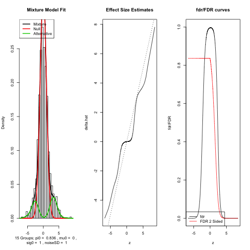

```
##
## Fitted Model: J = 15 groups
## ----------------------------
## null?         TRUE   FALSE   FALSE   FALSE   FALSE   FALSE   FALSE   FALSE   FALSE   FALSE   FALSE   FALSE   FALSE   FALSE   FALSE
##
## pi =     0.8362  0.0029  0.0136  0.0047  0.0168  0.0039  0.0086  0.0090  0.0029  0.0132  0.0091  0.0085  0.0081  0.0545  0.0080
##
## mu =          0.000   4.757  -3.744  -4.309   2.819   3.660  -2.513  -2.513   4.580  -2.513   2.793  -2.513  -2.513   3.487  -2.513
##
## sigma =  1.000   2.302   1.395   1.297   1.000   1.172   1.000   1.000   2.266   1.000   1.000   1.000   1.000   1.094   1.000
##
## noiseSD =    1
```

```r
mean((beta.mfdr.J3$effectSize - ss$beta)^2)
```

```
## [1] 0.693
```

```r
mean((beta.mfdr.J5$effectSize - ss$beta)^2)
```

```
## [1] 0.6951
```

```r
mean((beta.mfdr.J7$effectSize - ss$beta)^2)
```

```
## [1] 0.6952
```

```r
mean((beta.mfdr.J9$effectSize - ss$beta)^2)
```

```
## [1] 0.6946
```

```r
mean((beta.mfdr.J15$effectSize - ss$beta)^2)
```

```
## [1] 0.6903
```

```r
mean((beta.ash$PosteriorMean - ss$beta)^2)
```

```
## [1] 0.6256
```

```r
mean((beta.ash.u$PosteriorMean - ss$beta)^2)
```

```
## [1] 0.628
```

```r
mean((beta.ash.hu$PosteriorMean - ss$beta)^2)
```

```
## [1] 0.6341
```

[figure not shown]

```r
# This code mostly borrowed from the examples in mixFdr in R help
m = beta.mfdr.J15
mTrue = list(pi = c(0.8, 0.2), mu = c(0, 0), sig = c(1, sqrt(5)))
par(mfcol = c(1, 1))
s = seq(-5, 5, by = 0.01)
trueFdr = fdrMixModel(s, mTrue, c(TRUE, FALSE))
fdrCurve = fdrMixModel(s, m, abs(m$mu - m$mu[1]) <= 0.002)  # this tells it which indices to consider null
plot(s, trueFdr, t = "l", main = "fdr - Black is true", xlab = "z", ylab = "fdr",
    ylim = c(0, 1))
lines(s, fdrCurve, col = 2)
points(ss$betahat, beta.ash$lfdr, col = 3)
points(ss$betahat, beta.ash.u$lfdr, col = 4)
points(ss$betahat, beta.ash.hu$lfdr, col = 5)
```

Of course, if we do something where alternatives are not centered on 0 then ash does worse!

```r
# This is the example from the mixfdr help example
z = c(rnorm(1000), rnorm(100, 3, 1))
m = mixFdr(z, J = 3, noiseSD = 1)
```

```
## Fitting preliminary model
## Fitting final model
```

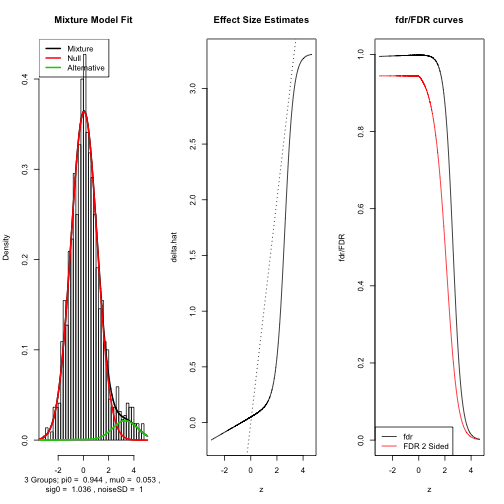

```
##
## Fitted Model: J = 3 groups
## ----------------------------
## null?         TRUE   FALSE   FALSE
##
## pi =     0.9443  0.0540  0.0018
##
## mu =          0.0533  3.3109 -0.4201
##
## sigma =  1.036   1.000   1.000
##
## noiseSD =    1
```

```r
s = seq(-5, 5, by = 0.01)
effCurve = effectSize(s, m)[, 1]
fdrCurve = fdrMixModel(s, m, abs(m$mu - m$mu[1]) <= 0.2)  # this tells it which indices to consider null

# compare to the Bayes estimator for this problem
mTrue = list(pi = c(10, 1)/11, mu = c(0, 3), sig = c(1, 1))
# note that the model parameters are in terms of the MARGINAL not of the
# prior
trueEff = effectSize(s, mTrue)[, 1]
trueFdr = fdrMixModel(s, mTrue, c(TRUE, FALSE))
par(mfrow = c(2, 1))
plot(s, trueEff, t = "l", main = "Effect Size - Black is true", xlab = "z",
    ylab = "E(delta|z)", ylim = c(-3, 3))
lines(s, effCurve, col = 2)
plot(s, trueFdr, t = "l", main = "fdr - Black is true", xlab = "z", ylab = "fdr",
    ylim = c(0, 1))


z.ash = ash(z, 1, mixcompdist = "halfuniform")
```

```
## [1] "Warning: Posterior SDs not yet implemented for uniform components"
```

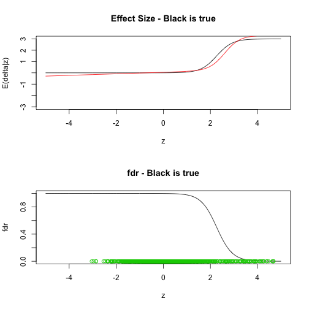

```r
points(z, z.ash$lfdr, col = 3)
```

Things to emphasise for paper:

- the number of components is not critical; the unimodal constraint is enough. You can increase the number of components arbitrarily and the likelihood remains bounded.
- the ability to incorporate item-specific measurement error
- the ability to compare a model in which effects are proportional to error with model in which effects
- unimodal distributions could be argued to be a primary motivation for shrinkage
- bayesian coverage intervals (attempt to) give much stronger guarantess than standard confidence intervals. Eg among the 0.95 intervals excluding 0, less than 5% should actually be 0?

Some advantages of the unimodal constraint: -more statsitically efficient (if true); show with small sample sizes.

- less sensitive to number of components? Can allow number to tend to infinity?
- may be less sensitive to local optima? could demonstrate this by looking at convergence more carefully, and comparing results with random starting points.
- it allows us to easily just vary sigma on a grid, and fit pi, which makes allowing different noise levels really easy!

## The number of components is not critical

OR - this section could be more generally about selecting between models (normal, uniforms etc) using log-likelihood.

[output not shown]

However, it is true that the normal distributions tend to yield smoother estimated underlying distributions. Similarly, using the posterior mean for \( \pi \), rather than the maximum likelihood estimate, tends to lead to somewhat smoother fitted distributions. In addition, with small amounts of data the underlying distributions are inevitably not well determined by the data, and the fits may vary depending on the underlying assumptions made (e.g. number of components or distribution of the components); however, even then shrinkage-based estimates of the betas can be relatively robust.

```r
set.seed(200)
sampsize = 50
beta = c(rnorm(sampsize, -1, 1), rnorm(sampsize, 1, 1))
betahat = beta + rnorm(2 * sampsize)

beta.ash.default = ash(betahat, 1)  #run with default parameters for comparison
beta.ash.vb.default = ash(betahat, 1, VB = TRUE)  #run with default parameters for comparison

beta.ash.100 = ash(betahat, 1, mixsd = seq(0.1, 5, length = 100))
beta.ash.100u = ash(betahat, 1, mixcompdist = "uniform", mixsd = seq(0.1, 5,
    length = 100))
```

```
## [1] "Warning: Posterior SDs not yet implemented for uniform components"
```

```r
beta.ash.100hu = ash(betahat, 1, mixcompdist = "halfuniform", mixsd = seq(0.1,
    5, length = 100))
```

```
## [1] "Warning: Posterior SDs not yet implemented for uniform components"
```

```r
beta.ash.vb.100 = ash(betahat, 1, mixsd = seq(0.1, 5, length = 100), VB = TRUE)
beta.ash.vb.100u = ash(betahat, 1, mixcompdist = "uniform", mixsd = seq(0.1,
    5, length = 100), VB = TRUE)
```

```
## [1] "Warning: Posterior SDs not yet implemented for uniform components"
```

```r
beta.ash.vb.100hu = ash(betahat, 1, mixcompdist = "halfuniform", mixsd = seq(0.1,
    5, length = 100), VB = TRUE)
```

```
## [1] "Warning: Posterior SDs not yet implemented for uniform components"
```

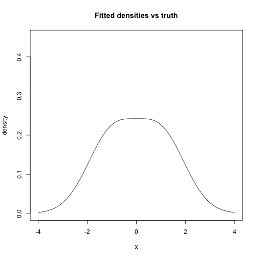

```r
x = seq(-4, 4, length = 1000)
plot(x, 0.5 * dnorm(x, -1, 1) + 0.5 * dnorm(x, 1, 1), col = 1, ylim = c(0, 0.45),
    main = "Fitted densities vs truth", type = "l", ylab = "density")
```

```r
lines(x, density(beta.ash.default, x), col = 2)
```

```
## Error: 'x' and 'y' lengths differ
```

```r
lines(x, density(beta.ash.100, x), col = 2)
```

```
## Error: 'x' and 'y' lengths differ
```

```r
lines(x, density(beta.ash.100u, x), col = 3)
```

```
## Error: 'x' and 'y' lengths differ
```

```r
lines(x, density(beta.ash.100hu, x), col = 4)
```

```
## Error: 'x' and 'y' lengths differ
```

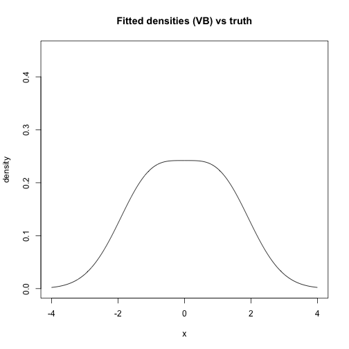

```r
plot(x, 0.5 * dnorm(x, -1, 1) + 0.5 * dnorm(x, 1, 1), col = 1, ylim = c(0, 0.45),
    main = "Fitted densities (VB) vs truth", type = "l", ylab = "density")
```

```r
lines(x, density(beta.ash.vb.default, x), col = 2)
```

```
## Error: 'x' and 'y' lengths differ
```

```r
lines(x, density(beta.ash.vb.100, x), col = 2, lty = 2)
```

```
## Error: 'x' and 'y' lengths differ
```

```r
lines(x, density(beta.ash.vb.100u, x), col = 3, lty = 2)
```

```
## Error: 'x' and 'y' lengths differ
```

```r
lines(x, density(beta.ash.vb.100hu, x), col = 4, lty = 2)
```

```
## Error: 'x' and 'y' lengths differ
```

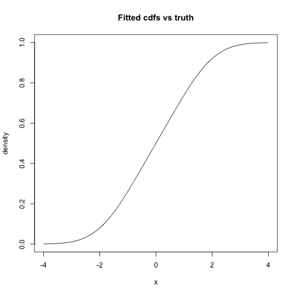

```r
plot(x, 0.5 * pnorm(x, -1, 1) + 0.5 * pnorm(x, 1, 1), col = 1, main = "Fitted cdfs vs truth",
    type = "l", ylab = "density")
```

```r
lines(x, cdf.ash(beta.ash.100, x), col = 2, lty = 2)
```

```
## Error: 'x' and 'y' lengths differ
```

```r
lines(x, cdf.ash(beta.ash.100u, x), col = 3, lty = 2)
```

```
## Error: 'x' and 'y' lengths differ
```

```r
lines(x, cdf.ash(beta.ash.100hu, x), col = 4, lty = 2)
```

```
## Error: 'x' and 'y' lengths differ
```

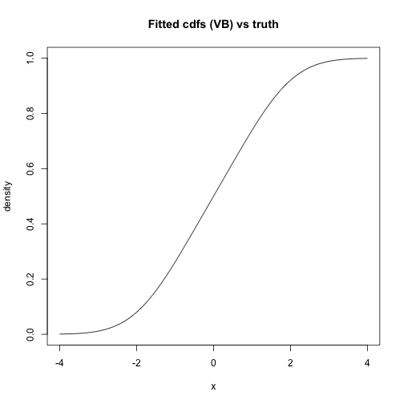

```r
plot(x, 0.5 * pnorm(x, -1, 1) + 0.5 * pnorm(x, 1, 1), col = 1, main = "Fitted cdfs (VB) vs truth",
    type = "l", ylab = "density")
```

```r
lines(x, cdf.ash(beta.ash.vb.default, x), col = 2, lty = 2)
```

```
## Error: 'x' and 'y' lengths differ
```

```r
lines(x, cdf.ash(beta.ash.vb.100, x), col = 2, lty = 2)
```

```
## Error: 'x' and 'y' lengths differ
```

```r
lines(x, cdf.ash(beta.ash.vb.100u, x), col = 3, lty = 2)
```

```
## Error: 'x' and 'y' lengths differ
```

```r
lines(x, cdf.ash(beta.ash.vb.100hu, x), col = 4, lty = 2)
```

```
## Error: 'x' and 'y' lengths differ
```

```r
c(loglik.ash(beta.ash.100, betahat, 1), get_loglik(beta.ash.100u), get_loglik(beta.ash.100hu))
```

```
## [1] -198.2 -198.0 -197.6
```

```r
c(loglik.ash(beta.ash.vb.100, betahat, 1), loglik.ash(beta.ash.vb.100u, betahat,
    1), loglik.ash(beta.ash.vb.100hu, betahat, 1))
```

```
## [1] -208.9 -199.3 -199.4
```

```r
rmse = function(a, b) {
    sqrt(mean((a$PosteriorMean - b)^2))
}
c(rmse(beta.ash.default, beta), rmse(beta.ash.100, beta), rmse(beta.ash.100u,
    beta), rmse(beta.ash.100hu, beta), rmse(beta.ash.vb.default, beta), rmse(beta.ash.vb.100,
    beta), rmse(beta.ash.vb.100u, beta), rmse(beta.ash.vb.100hu, beta))
```

```
## [1] 0.6954 0.6933 0.6869 0.6791 0.7552 0.7365 0.7104 0.7104
```

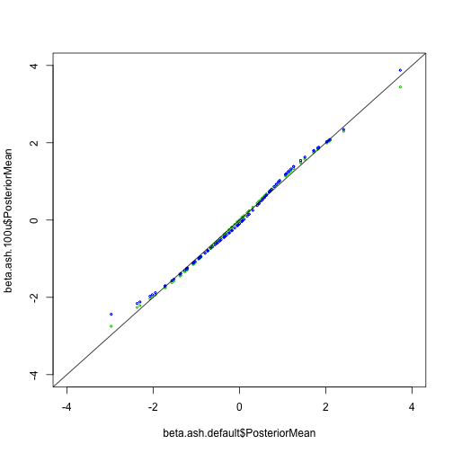

```r
plot(beta.ash.default$PosteriorMean, beta.ash.100u$PosteriorMean, col = 3, cex = 0.4,
    xlim = c(-4, 4), ylim = c(-4, 4))
points(beta.ash.default$PosteriorMean, beta.ash.100hu$PosteriorMean, col = 4,
    cex = 0.4)
abline(a = 0, b = 1)
```

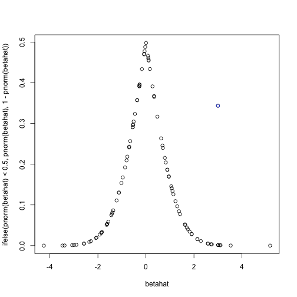

```r
plot(betahat, ifelse(pnorm(betahat) < 0.5, pnorm(betahat), 1 - pnorm(betahat)))
points(betahat, beta.ash.default$localfsr, col = 2)
points(betahat, beta.ash.100u$localfsr, col = 3)
points(betahat, beta.ash.100hu$localfsr, col = 4)
```

```r
sampsize = 5000
beta = c(rnorm(sampsize, -1, 1), rnorm(sampsize, 1, 1))
betahat = beta + rnorm(2 * sampsize)

beta.ash = ash(betahat, 1)
beta.ash.u = list()
for (i in 1:10) {
    beta.ash.u[[i]] = ash(betahat, 1, mixcompdist = "uniform", mixsd = seq(0.1,
        5, length = 10 * i))
}
```

[output not shown]

```r
plot(beta.ash, -4, 4, col = 2)
```

```
## Error: 'x' and 'y' lengths differ
```

```r
x = seq(-4, 4, length = 1000)
lines(x, 0.5 * dnorm(x, -1, 1) + 0.5 * dnorm(x, 1, 1), col = 1)
```

```
## Error: plot.new has not been called yet
```

```r
for (i in 1:4) {
    lines(x, density(beta.ash.u[[i]], x), col = 2 + i)
}
```

```
## Error: 'x' and 'y' lengths differ
```

```r
plot(unlist(lapply(beta.ash.u, ashr:::get_loglik)))
```

[output not shown]

```r
ss = simdata(10000, 8000, 0, 2, 1)

beta.ash = ash(ss$betahat, ss$betasd, auto = FALSE)
```

```
## Error: unused argument (auto = FALSE)
```

```r
beta.ash.auto = ash(ss$betahat, ss$betasd, auto = TRUE)
```

```
## Error: unused argument (auto = TRUE)
```

```r
# these to test the VB version
beta.ash.vb.uniform = ash(ss$betahat, ss$betasd, VB = TRUE, prior = "uniform")
beta.ash.vb.nullbiased = ash(ss$betahat, ss$betasd, VB = TRUE, prior = "nullbiased")
beta.ash.pm = ash(ss$betahat, ss$betasd, usePointMass = TRUE)
```

```
## Error: unused argument (usePointMass = TRUE)
```

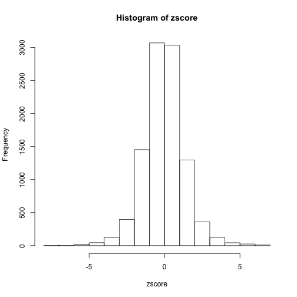

```r
# compute the usual zscore and corresponding p value
zscore = ss$betahat/ss$betasd

pval = pchisq(zscore^2, df = 1, lower.tail = F)
qval = qvalue(pval)
hist(zscore)
```

Plot the fitted underlying distribution on top of true values for beta

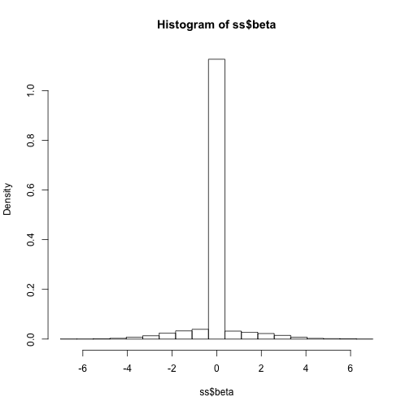

```r
hist(ss$beta, prob = TRUE, breaks = seq(-7, 7, length = 20))
```

```r
x = seq(-7, 7, length = 1000)
lines(x, density(beta.ash, x), col = 2)
```

```
## Error: 'x' and 'y' lengths differ
```

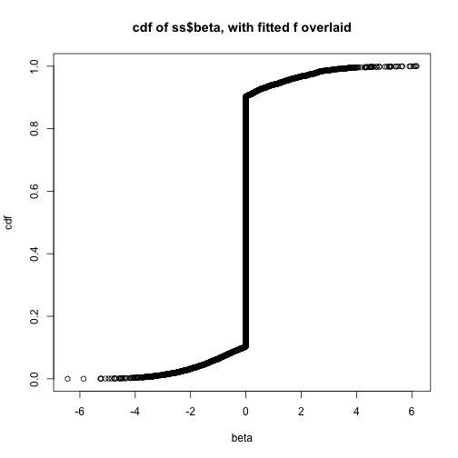

```r
plot(sort(ss$beta), (1:length(ss$beta))/length(ss$beta), main = "cdf of ss$beta, with fitted f overlaid",
    xlab = "beta", ylab = "cdf")
```

```r
lines(x, cdf.ash(beta.ash, x), col = 2, lwd = 2)
```

```
## Error: 'x' and 'y' lengths differ
```

```r
lines(x, cdf.ash(beta.ash.auto, x), col = 3, lwd = 2)
```

```
## Error: object 'beta.ash.auto' not found
```

```r
lines(x, cdf.ash(beta.ash.vb.uniform, x), col = 4, lwd = 2)
```

```
## Error: 'x' and 'y' lengths differ
```

```r
lines(x, cdf.ash(beta.ash.vb.null, x), col = 5, lwd = 2)
```

```
## Error: object 'beta.ash.vb.null' not found
```

```r
lines(x, cdf.ash(beta.ash.pm, x), col = 6, lwd = 2)
```

```
## Error: object 'beta.ash.pm' not found
```

[for testing: compare results with point mass and without]

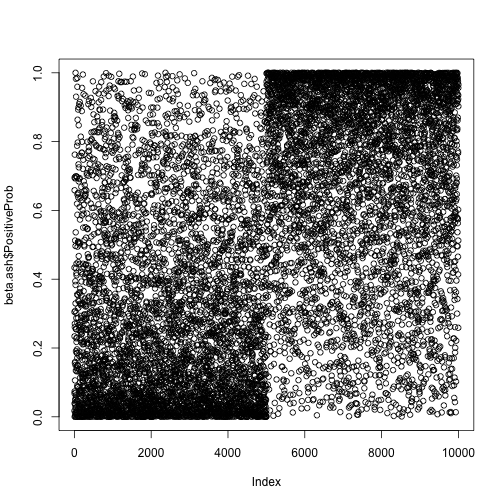

```r
plot(beta.ash$PositiveProb)
```

```r
points(beta.ash.pm$PositiveProb, col = 2)
```

```
## Error: object 'beta.ash.pm' not found
```

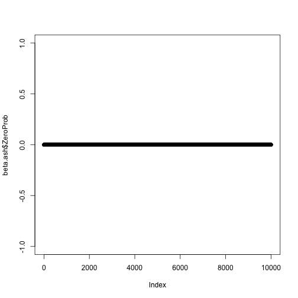

```r
plot(beta.ash$ZeroProb)
```

```r
points(beta.ash.pm$ZeroProb, col = 2)
```

```
## Error: object 'beta.ash.pm' not found
```

[for testing: compare with the results from the automatic way for selecting sigma]

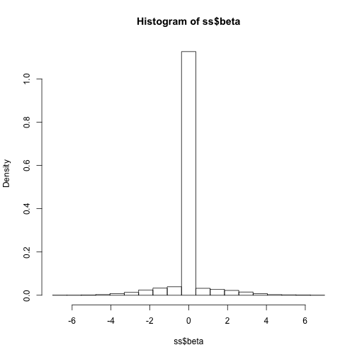

```r
hist(ss$beta, prob = TRUE, breaks = seq(-7, 7, length = 20))
```

```r
x = seq(-4, 4, length = 1000)
lines(x, density(beta.ash.auto, x), col = 2)
```

```
## Error: object 'beta.ash.auto' not found
```

```r
plot(beta.ash.auto$PosteriorMean, beta.ash$PosteriorMean, xlab = "Shrunk estimate from auto method",
    ylab = "Shrunk estimate from fixed method")
```

```
## Error: object 'beta.ash.auto' not found
```

```r
abline(a = 0, b = 1)
```

```
## Error: plot.new has not been called yet
```

```r
plot(beta.ash.auto$lfdr, beta.ash$lfdr, xlab = "lfdr from auto method", ylab = "ldfr from fixed method")
```

```
## Error: object 'beta.ash.auto' not found
```

```r
abline(a = 0, b = 1)
```

```
## Error: plot.new has not been called yet
```

```r
plot(beta.ash.auto$PosteriorMean, beta.ash.vb.uniform$PosteriorMean, xlab = "Shrunk estimate from auto method",
    ylab = "Shrunk estimate from vb method")
```

```
## Error: object 'beta.ash.auto' not found
```

```r
points(beta.ash.auto$PosteriorMean, beta.ash.vb.null$PosteriorMean, col = 2)
```

```
## Error: object 'beta.ash.auto' not found
```

```r
abline(a = 0, b = 1)
```

```
## Error: plot.new has not been called yet
```

```r
plot(beta.ash.auto$lfdr, beta.ash.vb.uniform$lfdr, xlab = "lfdr from auto method",
    ylab = "ldfr from vb method")
```

```
## Error: object 'beta.ash.auto' not found
```

```r
points(beta.ash.auto$lfdr, beta.ash.vb.null$lfdr, col = 2)
```

```
## Error: object 'beta.ash.auto' not found
```

```r
abline(a = 0, b = 1)
```

```
## Error: plot.new has not been called yet
```

[figure not shown]

```r
plot(ss$betahat, beta.ash$PosteriorMean, xlab = "Observed betahat", ylab = "Estimated beta (posterior mean)",
    ylim = c(-7, 7), xlim = c(-7, 7))
abline(h = 0)
abline(a = 0, b = 1, col = 2)
```

### Some additional notes

#### Do we need a point mass at zero?

In some settings it is the convention to focus on testing whether \( \beta_j=0 \). However some dislike this focus, objecting that it is unlikely to be the case that \( \beta_j=0 \) exactly. For example, when comparing the average expression of a gene in human samples vs chimp samples, it might be considered unlikely that the expression is *exactly* the same in both. Whether or not \( \beta_j=0 \) is considered unlikely may depend on the context. However, in most contexts, finite data cannot distinguish between \( \beta_j=0 \) and \( \beta_j \) being very close to zero. Thus finite data cannot usually convince a skeptic that \( \beta_j \) is exactly zero, rather than just very small. In contrast it is easy to imagine data that would convince a doubter that \( \beta_j \) is truly non-zero. In this sense there is an assymetry between the inferences “\( \beta_j \) is zero” and “\( \beta_j \) is non-zero”, an assymetry that is reflected in the admonition “failure to reject the null does not imply it to be true”.

Thus any analysis that purports to distinguish between these cases must be making an assumption.

Consider two analyses of the same data, using two different “priors” \( g \) for \( \beta_j \), that effectively differ only in their assumptions about whether or not \( \beta_j \) can be exactly zero. For concreteness, consider \[ g_1(\cdot) = \pi \delta_0(\cdot) + (1-\pi) N(\cdot; 0,\sigma^2) \] and \[ g_2(\cdot) = \pi N(\cdot; 0, \epsilon^2) + (1-\pi) N(\cdot; 0, \sigma^2). \] If \( \epsilon^2 \) is sufficiently small, then these priors are “approximately the same”, and will lead to “approximately the same” posteriors and inferences in many senses. To discuss these, let \( p_j \) denote the posterior under prior \( g_j \). Then, for any given (small) \( \delta \), we will have \( p_1(|\beta_j|<\delta) \approx p_2(|\beta_j|< \delta) \). However, we will not have \( p_1(\beta_j=0) \approx p_2(\beta_j=0) \): the latter will always be zero, while the former could be appreciable.

What if, instead, we examine \( p_1(\beta_j >0) \) and \( p_2(\beta_j >0) \)? Again, these will differ. If this probability is big in the first analysis, say \( 1-\alpha \) with \( \alpha \) small, then it could be as big as \( 1-\alpha/2 \) in the second analysis. This is because if \( p_1(\beta_j>0)=1-\alpha \), then \( p_1(\beta_j=0) \) will often be close to \( \alpha \), so for small \( \epsilon \) \( p_2(\beta_j) \) will have mass \( \alpha \) near 0, of which half will be positive and half will be negative. Thus if we do an analysis without a point mass, but allow for mass near 0, then we may predict what the results would have been if we had used a point mass.

```r
beta.ash.pm = ash(ss$betahat, ss$betasd, usePointMass = TRUE)
```

```
## Error: unused argument (usePointMass = TRUE)
```

```r
print(beta.ash.pm)
```

```
## Error: object 'beta.ash.pm' not found
```

```r
print(beta.ash.auto)
```

```
## Error: object 'beta.ash.auto' not found
```

```r
plot(beta.ash.auto$localfsr, beta.ash.pm$localfsr, main = "comparison of ash localfsr, with and without point mass",
    xlab = "no point mass", ylab = "with point mass", xlim = c(0, 1), ylim = c(0,
        1))
```

```
## Error: object 'beta.ash.auto' not found
```

```r
abline(a = 0, b = 1)
```

```
## Error: plot.new has not been called yet
```

```r
abline(a = 0, b = 2)
```

```
## Error: plot.new has not been called yet
```

#### Comparison with qvalue

Here we compare ash \( q \) values with those from the qvalue package.

[figure not shown]

```r
plot(qval$q, beta.ash$qval, main = "comparison of ash and q value qvalues",
    xlab = "qvalue", ylab = "ash q values")
abline(a = 0, b = 1)
```

[figure not shown]

```r
o = order(beta.ash$qval)
plot(cumsum(ss$null[o])/(1:10000), qval$qval[o], col = 2, type = "l", xlab = "actual FDR",
    ylab = "q value", main = "Comparison of actual FDR with q value")
lines(cumsum(ss$null[o])/(1:10000), beta.ash$qval[o])
abline(a = 0, b = 1)
```

### Miscellaneous

code and text below here is work in progress and untidied.

Here we simulate data, effectively as in Efron, 2008, Section 7.

```r
truenull = c(rep(0, 1000), rep(1, 9000))
beta = c(rnorm(1000, -3, 1), rep(0, 9000))
s = rep(1, 10000)
betahat = rnorm(10000, beta, s)

beta.ash = ash(betahat, s)
```

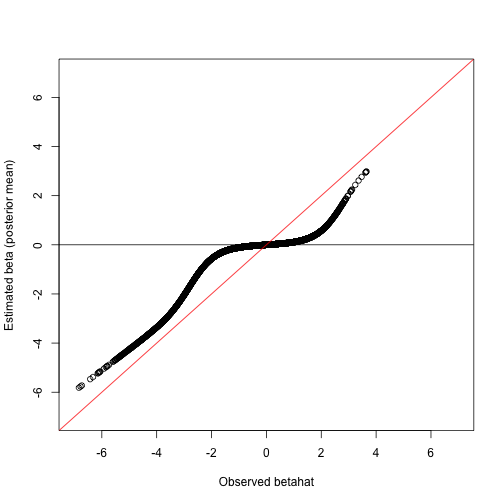

```r
# compute the usual zscore and corresponding p value
zscore = betahat/s
pval = pchisq(zscore^2, df = 1, lower.tail = F)
qval = qvalue(pval)

plot(betahat, beta.ash$PosteriorMean, xlab = "Observed betahat", ylab = "Estimated beta (posterior mean)",
    ylim = c(-7, 7), xlim = c(-7, 7))
abline(h = 0)
abline(a = 0, b = 1, col = 2)
```

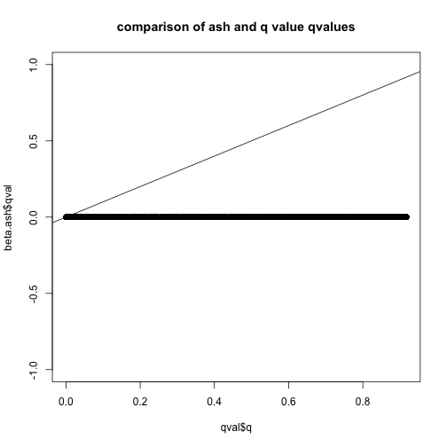

```r
plot(qval$q, beta.ash$qval, main = "comparison of ash and q value qvalues")
abline(a = 0, b = 1)
```

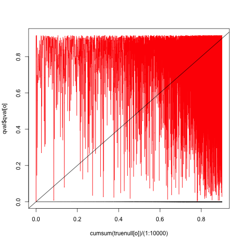

```r
o = order(beta.ash$qval)

plot(cumsum(truenull[o])/(1:10000), qval$qval[o], col = 2, type = "l")
lines(cumsum(truenull[o])/(1:10000), beta.ash$qval[o])
abline(a = 0, b = 1)
```

```r
pos = betahat > 0
betapos.ash = ash(betahat[pos], s[pos])
betaneg.ash = ash(betahat[!pos], s[!pos])
lfdr = rep(0, length(betahat))
lfdr[pos] = betapos.ash$lfdr
lfdr[!pos] = betaneg.ash$lfdr
qv = qval.from.localfdr(lfdr)
```

```
## Error: could not find function "qval.from.localfdr"
```

```r
o = order(qv)
```

```
## Error: object 'qv' not found
```

```r
plot(cumsum(truenull[o])/(1:10000), qv[o], type = "l")
```

```
## Error: object 'qv' not found
```

```r
abline(a = 0, b = 1)
```

```
## Error: plot.new has not been called yet
```

No, that's not it.

So maybe it is the non-monotonic behaviour of the true beta values in this case. Let's try putting in a component at -1.5 to make the data fit this assumption better.

### Illustration of halfuniform method

```r
truenull = c(rep(0, 2000), rep(1, 8000))
beta = c(rnorm(1000, -3, 1), rnorm(1000, -1.5, 1), rep(0, 8000))
s = rep(1, 10000)
betahat = rnorm(10000, beta, s)

beta.ash = ash(betahat, s)
beta.ash.halfu = ash(betahat, s, "halfuniform")
```

```
## Error: 'arg' should be one of "shrink", "fdr"
```

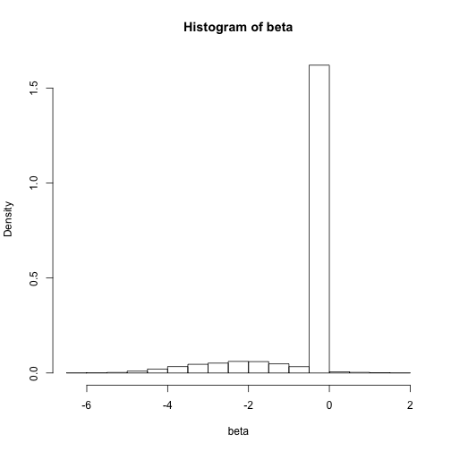

```r
hist(beta, prob = TRUE)
```

```r
x = seq(-8, 4, length = 1000)
lines(x, density(beta.ash, x), col = 2)
```

```
## Error: 'x' and 'y' lengths differ
```

```r
lines(x, density(beta.ash.halfu, x), col = 3)
```

```
## Error: object 'beta.ash.halfu' not found
```

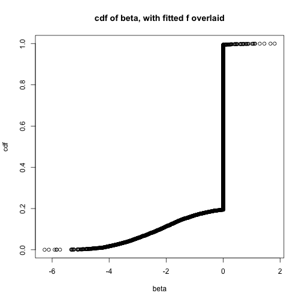

```r
plot(sort(beta), (1:length(beta))/length(beta), main = "cdf of beta, with fitted f overlaid",
    xlab = "beta", ylab = "cdf")
```

```r
lines(x, cdf.ash(beta.ash, x), col = 2, lwd = 2)
```

```
## Error: 'x' and 'y' lengths differ
```

```r
lines(x, cdf.ash(beta.ash.halfu, x), col = 3, lwd = 2)
```

```
## Error: object 'beta.ash.halfu' not found
```

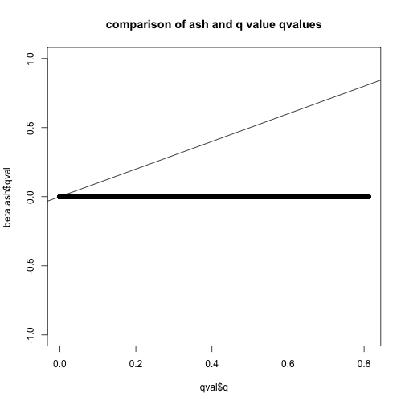

```r
# compute the usual zscore and corresponding p value
zscore = betahat/s
pval = pchisq(zscore^2, df = 1, lower.tail = F)
qval = qvalue(pval)
plot(qval$q, beta.ash$qval, main = "comparison of ash and q value qvalues")
abline(a = 0, b = 1)
```

```r
o = order(qval$qval)
plot(cumsum(truenull[o])/(1:10000), qval$qval[o], col = 1, type = "l")
o = order(beta.ash$qval)
lines(cumsum(truenull[o])/(1:10000), beta.ash$qval[o], col = 2)
o2 = order(beta.ash.halfu$qval)
```

```
## Error: object 'beta.ash.halfu' not found
```

```r
lines(cumsum(truenull[o2])/(1:10000), beta.ash.halfu$qval[o2], col = 3)
```

```
## Error: object 'o2' not found
```

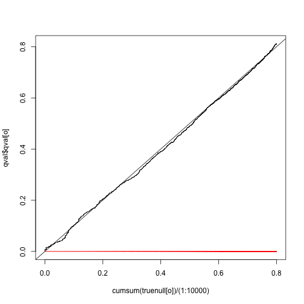

```r
abline(a = 0, b = 1)
```

### Motivation

It is common in statistics that you measure many “similar” things imperfectly, and wish to estimate their values. The situation arises commonly in the kinds of genomics applications I am often involved in, but also in other areas of statistics. In genomics, for example, a very common goal is to compare the mean expression (activity) level of many genes in two conditions. Let \( \mu^0_j \) and \( \mu^1_j \) denote the mean expression of gene \( j \) (\( j=1,\dots,J \)) in the two conditions, and define \( \beta_j:= \mu^0_j - \mu^1_j \) to be the difference. Typically expression measurements are made on only a small number of samples in each condition - sometimes as few as one sample in each condition. Thus the error in estimates of \( \mu^0_j \) and \( \mu^1_j \) is appreciable, and the error in estimates of \( \beta_j \) still greater.

A fundamental idea is that the measurements of \( \beta_j \) for each gene can be used to improve inference for the values of \( \beta \) for other genes.

Note on multiple comparisons: it isn't really a “problem” but an “opportunity”. This viewpoint also espoused by Greenland and Robins. It isn't the number of tests that is relevant (the false discovery rate at a given threshold does not depend on the number of tests). It is the *results* of the tests that are relevant.

Performing multiple comparisons, or multiple tests, is often regarded as a “problem”. However, here we regard it instead as an opportunity - an opportunity to combine (or “pool”) information across tests or comparisons.

Imagine that you are preparing to perform 1 million tests, each based on a \( Z \) score that is assumed to be \( N(0,1) \) under the null. You first order these tests randomly, and begin by performing the first test, which returns a \( Z \) score of 4. At this point you are interrupted by a friend, who asks how the analysis is going. “It's early days, but looking promising” you reply. Well, who wouldn't? If the aim is to find lots of significant differences, a strong first result is surely a good outcome.

At this point you have reason to expect that many of the subsequent tests also output strong results.

Now consider two alternative scenarios for the remaining 999,999 tests. In the first scenario, the remaining tests produce \( Z \) values that fit very well with the null, closely following a standard normal distribution; in the second scenario a large proportion of the remaining tests, say 50 percent, show outcomes that lie outside of \( [-4,4] \).

If your friend enquired after your analysis again, your response would surely differ in the first scenario (“Oh, it didn't pan out so well after all”) vs the second (“It went great”). Further, in the first scenario, if your friend pressed you further about the results of the first test, you would likely, I think, be inclined to put them down to chance. In contrast, in the second scenario, the first test turned out to be, as you hoped, a harbinger of good things to come, and in this scenario you would likely regard that test as likely corresponding to a true discovery.

The key point is that it is the *outcomes* of the tests, not the *number* of tests, that impacts interpretation of that first test.

(Some may by pondering whether the fact that you are about to perform another 999,999 tests should be considered pertinent in responding to your friend. Our view is that it is irrelevant. The standard frequentist framework would disagree, because it requires the analyst to consider hypothetical repetitions of the “experiment”, and so the fact that the experiment consists of a million tests is pertinent. However, this argument is a distraction from the main point.)

Focussing on the number of tests performed can be seen as an approximation.

The standard argument is that, when performing multiple tests, some will be significant just by chance.